# 第9回 混合正規分布によるクラスタリングと、BICで選ぶ群の数

ペンギンの体の測り方から、種は分かれるか

# 導入

## 第8回は星、今日はペンギン

① 今日のデータ●○

- 第8回は、星をk-meansと階層的クラスタリングで分けた
- k-meansは丸い群しか探せず、細長い帯を輪切りにした
- 今日は、群の形が楕円でもよい分け方を使う

## 南極のペンギンの公開データ

① 今日のデータ●●

- 南極のパーマー基地の研究者が、近くの3つの島でペンギンを測った
- その測った値が、誰でも使える公開データ（CC0）として配られている
- 統計の教材として、世界中で使われているデータ

## 3種のペンギン

② 場面●○

- アデリー・ヒゲ・ジェンツーの3種
- 見た目はよく似ている。体の大きさやくちばしの形が、少しずつ違う
- 研究者は、種の名前を記録している。でも、測った値だけで見分けられるか

## 決めたいこと

② 場面●●

- 種の名前を使わず、体の測り方だけで、ペンギンを群に分けたい
- 分けた群が、種と合うか
- 合うなら、データから見て何種類とみなせるか

## 手元のデータ

③ 手元のデータ●○

- 1行が1羽。344羽
- 測った列は4本：くちばしの長さ・深さ、ひれの長さ、体重
- ほかに種・島・性別・年。これらは分けたあとの答え合わせだけに使う

## データをのぞく

③ 手元のデータ●●

|  | 0 | 1 | 2 |
| --- | --- | --- | --- |
| species | Adelie | Adelie | Adelie |
| island | Torgersen | Torgersen | Torgersen |
| bill_length_mm | 39.1 | 39.5 | 40.3 |
| bill_depth_mm | 18.7 | 17.4 | 18.0 |
| flipper_length_mm | 181.0 | 186.0 | 195.0 |
| body_mass_g | 3750.0 | 3800.0 | 3250.0 |
| sex | male | female | female |
| year | 2007 | 2007 | 2007 |

- 縦横を入れ替えて表示した。列の意味は、1節で読む

## 最後に出す答え

④ 今日の問い●○

- 体の測り方だけで分けると、3つの種が分かれるか
- 分かれるなら、データから見て何種類とみなせるか

## 今日の問い

④ 今日の問い●●

体の測り方だけで、ペンギンの種は分かれるか。何種類とみなせるか？

## もう1つのねらい：入れ子のfor

⑤ もう1つのねらい●

- `for`の中に`for`を入れて、2つの選び方のすべての組を試し、表にためられるようになる
- 群の数と群の形の、すべての組でBICという物差しを出す
- お手本ごとに、コードを1行ずつ読み、変数の中身を見る

# 今日の一周

## 結果だけで一度通す

⑥ 今日の一周●○○○○○○○

- まず、今日の解析を、結果だけで一度通して見る
- コードはあとで。どんな結論になるかを先に知っておく

## 一周①：くちばしを並べる

⑥ 今日の一周●●○○○○○○

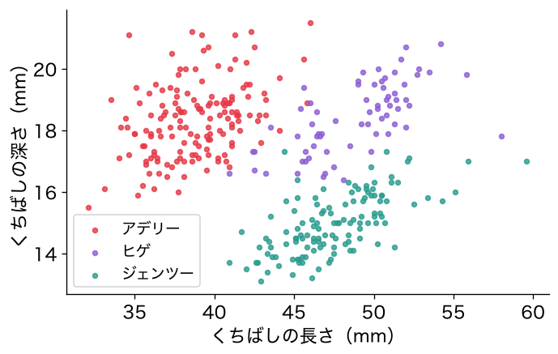

- 3種が、それぞれ斜めの楕円にまとまって見える

## 一周②：丸か、楕円か

⑥ 今日の一周●●●○○○○○

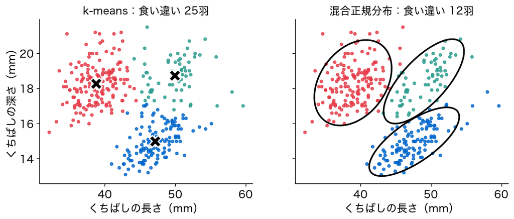

- 楕円を許す混合正規分布のほうが、種とよく合う

## 一周③：何種類とみなせる？

⑥ 今日の一周●●●●○○○○

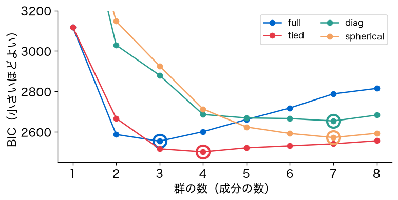

- BICで選ぶと、楕円の型（full）なら3。えっ、丸の型（spherical）なら7

## 一周④：言い切れないペンギン

⑥ 今日の一周●●●●●○○○

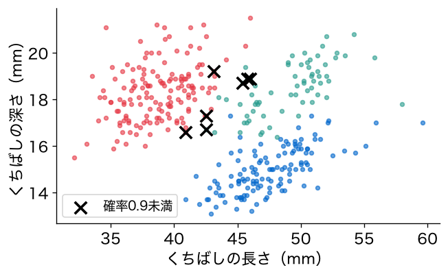

- どの群か、確率で言える。0.9に届かない羽が、種の境目にいる

## 一周⑤：7つの正体

⑥ 今日の一周●●●●●●○○

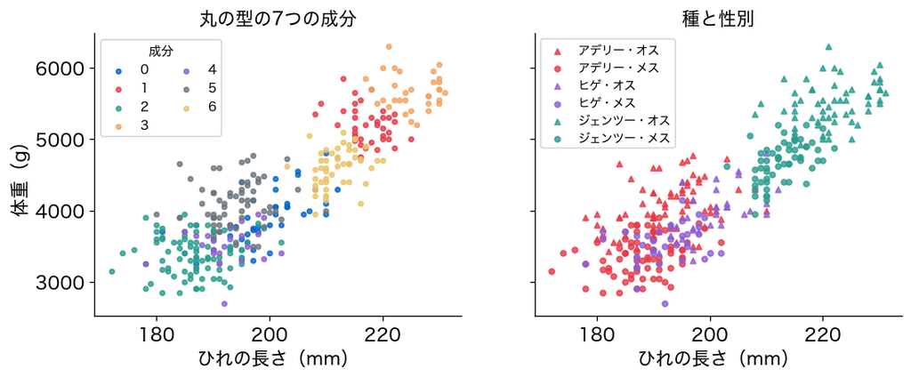

- 丸の型の7つの成分は、種と性別の組にかなり重なる

## 一周⑥：種の中にも群がある

⑥ 今日の一周●●●●●●●○

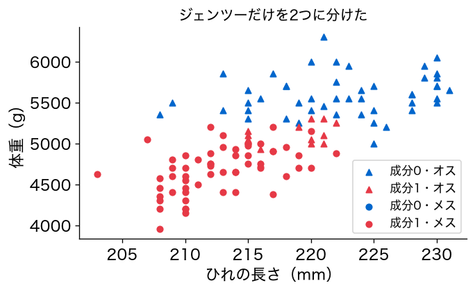

- ジェンツーだけを2つに分けると、メス（丸）はすべて1つの成分に入る

## 一周は5つの段

⑥ 今日の一周●●●●●●●●

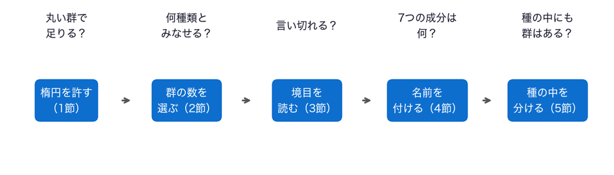

- このあと、5つの段の中身を、1つずつ開けていく

## 問いとやること①②

⑦ 問いとやること●○

- 楕円を許す：丸い群で足りる？ → くちばし2本でk-meansと混合正規分布に分け、種と比べる（1節）
- 群の数を選ぶ：何種類とみなせる？ → 4本の列で、群の数と型のすべての組のBICを、入れ子の`for`で出す（2節）

## 問いとやること③④⑤

⑦ 問いとやること●●

- 境目を読む：言い切れる？ → 所属の確率を出し、0.9に届かない羽を数えて図に印を付ける（3節）
- 名前を付ける：7つの成分は何？ → 成分ごとの平均を見て、使わなかった列（島・性別）と突き合わせる（4節）
- 種の中を分ける：種の中にも群はある？ → 1つの種だけを2つに分け、性別と突き合わせる（5節）

## 今日の進め方

⑧ 今日の進め方●

- 段ごとに、スライドで聞く → ノートで実行して答える
- 段の終わりの「ノートへ」で、予想を書き、1か所を替えて実行し、予想と比べる
- 予想は外れてかまわない

# 0. 準備

## まずは道具を呼び出す

- 0節は、道具を呼び出すだけ。ノートで1節と続けて実行する

# 1. 丸い群で足りる？

## 段1：楕円を許す

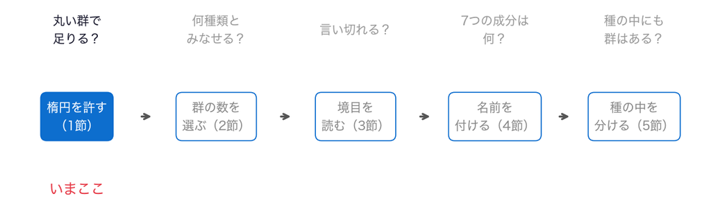

- 問い：k-meansの丸い群で、ペンギンの種は分かれるか

## お手本：表を読み込む

1節 ① 読み込む●○

```python
# データはこのリポジトリから読み込む
DATA_DIR = ('https://raw.githubusercontent.com/k0heiun0/'
            'applied_exercise_preview/main/shared/data')
raw = pd.read_csv(f'{DATA_DIR}/penguins.csv')
print(len(raw), '羽')
raw.head(3)
```

```
344 羽
```

## 1行ずつ：表を読み込む

1節 ① 読み込む●●

```python
# データはこのリポジトリから読み込む
DATA_DIR = ('https://raw.githubusercontent.com/k0heiun0/'
            'applied_exercise_preview/main/shared/data')
raw = pd.read_csv(f'{DATA_DIR}/penguins.csv')
print(len(raw), '羽')
raw.head(3)
```

- `DATA_DIR`の行：データの置き場所を`DATA_DIR`にしまう
- `pd.read_csv`の行：置き場所の`penguins.csv`を読み、表`raw`にしまう
- `print`と`head`の行：羽の数を表示し、先頭3行を見る

## 8本の列

1節 ② 列の意味●

| 列 | 意味 |
| --- | --- |
| `species`・`island` | 種・島 |
| `bill_length_mm`・`bill_depth_mm` | くちばしの長さ・深さ（mm）。深さは上下の厚み |
| `flipper_length_mm`・`body_mass_g` | ひれ（翼）の長さ（mm）・体重（g） |
| `sex`・`year` | 性別・測った年 |

## お手本：列と値を日本語に

1節 ③ 日本語に●○

```python
names = {'species': '種', 'island': '島',
         'bill_length_mm': 'くちばしの長さ',
         'bill_depth_mm': 'くちばしの深さ',
         'flipper_length_mm': 'ひれの長さ',
         'body_mass_g': '体重', 'sex': '性別', 'year': '年'}
kana = {'Adelie': 'アデリー', 'Chinstrap': 'ヒゲ',
        'Gentoo': 'ジェンツー', 'Biscoe': 'ビスコー',
        'Dream': 'ドリーム', 'Torgersen': 'トージャーセン',
        'male': 'オス', 'female': 'メス'}
df = raw.rename(columns=names).replace(kana)
df.head(3)
```

|  | 種 | 島 | くちばしの長さ | くちばしの深さ | ひれの長さ | 体重 | 性別 | 年 |
| --- | --- | --- | --- | --- | --- | --- | --- | --- |
| 0 | アデリー | トージャーセン | 39.1 | 18.7 | 181.0 | 3750.0 | オス | 2007 |
| 1 | アデリー | トージャーセン | 39.5 | 17.4 | 186.0 | 3800.0 | メス | 2007 |
| 2 | アデリー | トージャーセン | 40.3 | 18.0 | 195.0 | 3250.0 | メス | 2007 |

## 1行ずつ：列と値を日本語に

1節 ③ 日本語に●●

```python
names = {'species': '種', 'island': '島',
         'bill_length_mm': 'くちばしの長さ',
         'bill_depth_mm': 'くちばしの深さ',
         'flipper_length_mm': 'ひれの長さ',
         'body_mass_g': '体重', 'sex': '性別', 'year': '年'}
kana = {'Adelie': 'アデリー', 'Chinstrap': 'ヒゲ',
        'Gentoo': 'ジェンツー', 'Biscoe': 'ビスコー',
        'Dream': 'ドリーム', 'Torgersen': 'トージャーセン',
        'male': 'オス', 'female': 'メス'}
df = raw.rename(columns=names).replace(kana)
df.head(3)
```

- 1〜5行目：元の列の名前を鍵、日本語の名前を値にした辞書（第5回）
- 6〜9行目：表の中の値（種・島・性別）を、日本語にする辞書
- 10行目：列の名前を替え（`rename`）、値も替えて（`replace`）、表`df`にしまう

## お手本：欠測の羽を外す

1節 ④ 欠測●○○

```python
cols = ['くちばしの長さ', 'くちばしの深さ', 'ひれの長さ', '体重']
df = df.dropna(subset=cols).reset_index(drop=True)
print(len(df), '羽')
```

```
342 羽
```

- 344羽から342羽になった。4本の測った値がすべて欠けた羽を外した

## 1行ずつ：欠測の羽を外す

1節 ④ 欠測●●○

```python
cols = ['くちばしの長さ', 'くちばしの深さ', 'ひれの長さ', '体重']
df = df.dropna(subset=cols).reset_index(drop=True)
print(len(df), '羽')
```

- 1行目：分けるのに使う4本の列の名前を、リスト`cols`にしまう
- 2行目：`cols`のどれかが欠測（NaN）の行を外し（`dropna`）、行の番号を振り直す
- 3行目：残った羽の数を表示する

## 性別の欠測は残す

1節 ④ 欠測●●●

```python
print(df['性別'].isna().sum(), '羽')
```

```
9 羽
```

- 性別が欠測の羽が、まだ9羽ある。性別は分けるのに使わないので、外さない
- 答え合わせで性別を数えるときだけ、この9羽は数に入らない

## お手本：くちばしを描く

1節 ⑤ くちばし●○○○○

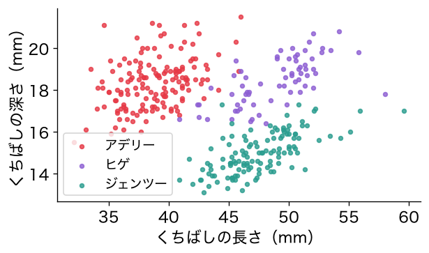

```python
for s in ['アデリー', 'ヒゲ', 'ジェンツー']:
    d = df[df['種'] == s]
    plt.scatter(d['くちばしの長さ'], d['くちばしの深さ'],
                s=10, label=s)
plt.legend()
plt.xlabel('くちばしの長さ（mm）')
plt.ylabel('くちばしの深さ（mm）')
plt.show()
```

## 1行ずつ：くちばしを描く

1節 ⑤ くちばし●●○○○

```python
for s in ['アデリー', 'ヒゲ', 'ジェンツー']:
    d = df[df['種'] == s]
    plt.scatter(d['くちばしの長さ'], d['くちばしの深さ'],
                s=10, label=s)
plt.legend()
plt.xlabel('くちばしの長さ（mm）')
plt.ylabel('くちばしの深さ（mm）')
plt.show()
```

- 1・2行目：種の名前を1つずつ取り、その種の羽だけの表`d`を作る
- 3・4行目：横に長さ、縦に深さをとって点を打つ。`label`で種の名前を付ける
- 5行目：種の名前の見出し（凡例）を出す

## 種の中では、右上がり

1節 ⑤ くちばし●●●○○

- 3種それぞれ、くちばしが長いほど深い。斜めの楕円
- ところが全体で見ると、長いほど浅い向き
- 数で確かめる

## お手本：相関係数を比べる

1節 ⑤ くちばし●●●●○

```python
print(df['くちばしの長さ'].corr(df['くちばしの深さ']).round(2))
for s in ['アデリー', 'ヒゲ', 'ジェンツー']:
    d = df[df['種'] == s]
    print(s, d['くちばしの長さ'].corr(d['くちばしの深さ']).round(2))
```

```
-0.24
アデリー 0.39
ヒゲ 0.65
ジェンツー 0.64
```

## 1行ずつ：相関係数を比べる

1節 ⑤ くちばし●●●●●

```python
print(df['くちばしの長さ'].corr(df['くちばしの深さ']).round(2))
for s in ['アデリー', 'ヒゲ', 'ジェンツー']:
    d = df[df['種'] == s]
    print(s, d['くちばしの長さ'].corr(d['くちばしの深さ']).round(2))
```

- 1行目：全体の、長さと深さの相関係数（`corr`）を表示する
- 2〜4行目：種ごとに羽を取り出し、同じ相関係数を表示する
- 全体では負、種の中では正。群ごとに、傾いた楕円がある

## 標準化して、近さを測る

1節 ⑥ 標準化●○○

- 第8回と同じく、列の単位をそろえてから分ける
- まず、くちばしの2本だけで分ける（図で見られるように）

## お手本：くちばし2本を標準化

1節 ⑥ 標準化●●○

```python
from sklearn.preprocessing import StandardScaler
cols2 = ['くちばしの長さ', 'くちばしの深さ']
X2 = StandardScaler().fit_transform(df[cols2])
print(X2[:3].round(2))
```

```
[[-0.88  0.79]
 [-0.81  0.13]
 [-0.66  0.43]]
```

## 1行ずつ：くちばし2本を標準化

1節 ⑥ 標準化●●●

```python
from sklearn.preprocessing import StandardScaler
cols2 = ['くちばしの長さ', 'くちばしの深さ']
X2 = StandardScaler().fit_transform(df[cols2])
print(X2[:3].round(2))
```

- 1行目：標準化の道具を呼び出す
- 2・3行目：2本の列の名前を`cols2`にしまい、平均0・標準偏差1にそろえて配列`X2`にする
- 4行目：先頭3羽の値を見る

## お手本：k-meansで3つに

1節 ⑦ k-means●○

```python
from sklearn.cluster import KMeans
km = KMeans(3, n_init=10, random_state=0)
km.fit(X2)
pd.crosstab(df['種'], km.labels_)
```

| col_0 種 | 0 | 1 | 2 |
| --- | --- | --- | --- |
| アデリー | 0 | 147 | 4 |
| ジェンツー | 116 | 1 | 6 |
| ヒゲ | 9 | 5 | 54 |

## 1行ずつ：k-meansで3つに

1節 ⑦ k-means●●

```python
from sklearn.cluster import KMeans
km = KMeans(3, n_init=10, random_state=0)
km.fit(X2)
pd.crosstab(df['種'], km.labels_)
```

- 1〜3行目：k-meansを、群の数3で当てはめる（第8回）
- 4行目：種と群の番号の組ごとに、羽を数える（`pd.crosstab`）
- 群の番号は名前にすぎない。どの群がどの種かは、数を見て読む

## 種と食い違う羽を数える

1節 ⑧ 食い違い●○○○

- 群ごとに、いちばん多い種を、その群の種とみなす
- それ以外の種の羽が、食い違った羽
- 同じ数え方を何度も使うので、関数にする（第7回）

## お手本：食い違いを数える関数

1節 ⑧ 食い違い●●○○

```python
def n_miss(lab):
    ct = pd.crosstab(df['種'], lab)
    return len(df) - ct.max().sum()

print(n_miss(km.labels_), '羽')
```

```
25 羽
```

## 1行ずつ：食い違いを数える関数

1節 ⑧ 食い違い●●●○

```python
def n_miss(lab):
    ct = pd.crosstab(df['種'], lab)
    return len(df) - ct.max().sum()

print(n_miss(km.labels_), '羽')
```

- 2行目：種と群の番号の表を作る
- 3行目：列（群）ごとの最大を足すと、群の種と合う羽の数。全体から引いて返す
- 5行目：k-meansの群で数える

## k-meansの3つを見る

1節 ⑧ 食い違い●●●●

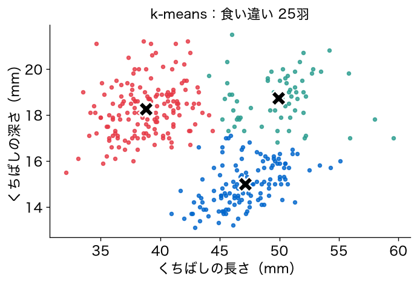

- 中心（×）からの距離で切るので、斜めの楕円の端が、となりの群に取られる

## 混合正規分布の考え

1節 ⑨ 混合正規分布●○○

- データは、いくつかの正規分布（成分）を重ねたものから出てきた、と考える
- 成分ごとに、平均・広がりと傾き（共分散）・割合を持つ
- 各点を、出てきたらしい成分に分ける

## 混合正規分布を図で

1節 ⑨ 混合正規分布●●○

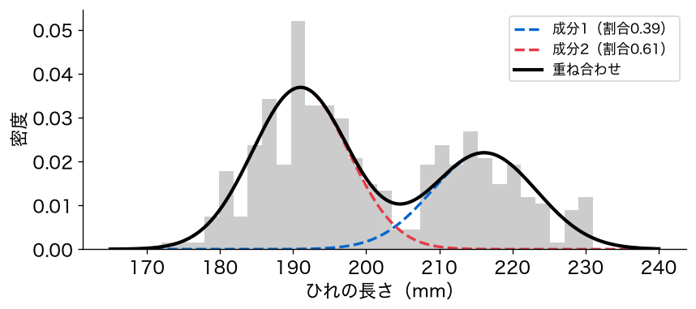

- ひれの長さの分布を、2つの正規分布の重ね合わせで表した（灰色が実際の分布）

## 式：混合正規分布

1節 ⑨ 混合正規分布●●●

$k$ 個の成分を、割合 $\pi_j$ で重ねる。

$$p(x) = \sum_{j=1}^{k} \pi_j \, N(x \mid \mu_j, \Sigma_j)$$

- $\mu_j$ は成分 $j$ の平均、$\Sigma_j$ は共分散（広がりと傾き）
- $\pi_j$ は割合で、足すと1

## お手本：混合正規分布で3つに

1節 10 3つに分ける●○○

```python
from sklearn.mixture import GaussianMixture
gm2 = GaussianMixture(3, n_init=5, random_state=0)
gm2.fit(X2)
lab2 = gm2.predict(X2)
print(n_miss(lab2), '羽')
```

```
12 羽
```

- 食い違いは、k-meansの半分ほど

## 1行ずつ：混合正規分布で3つに

1節 10 3つに分ける●●○

```python
from sklearn.mixture import GaussianMixture
gm2 = GaussianMixture(3, n_init=5, random_state=0)
gm2.fit(X2)
lab2 = gm2.predict(X2)
print(n_miss(lab2), '羽')
```

- 1・2行目：混合正規分布の道具を呼び出し、成分の数3で準備する（出発点は5通り）
- 3・4行目：当てはめ、羽ごとにいちばん出てきたらしい成分の番号を出す
- 5行目：食い違った羽を数える

## 中身を見る：割合と平均

1節 10 3つに分ける●●●

```python
print(gm2.weights_.round(2))
print(gm2.means_.round(2))
```

```
[0.35 0.46 0.19]
[[ 0.68 -1.11]
 [-0.91  0.59]
 [ 0.93  0.63]]
```

- 割合は、3つの成分にどのくらいの羽が入るか。平均は標準化した単位

## 丸と楕円を並べる

1節 11 比べる●○

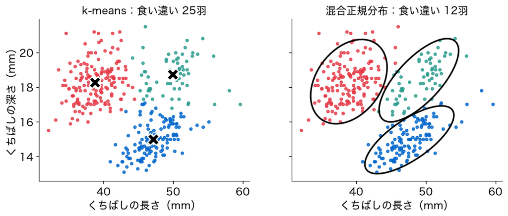

- 混合正規分布の楕円（平均から標準偏差2つぶん）は、種ごとの斜めの塊をなぞる

## 重要：楕円の群を許す

1節 11 比べる●●

k-meansは、どの群も同じ大きさの丸と考えて分ける。混合正規分布は、群ごとに広がりと傾きを持つ楕円を許す。

## 結果を見る前に、予想を書く

1節 12 予想●

- 群の数を、データに選ばせたら、3を選ぶだろうか
- 予想を書いてから、2節へ進む

## TODO①：列を4本にする

1節 13 列を替える●

```python
# TODO: cols2 を cols に替えて実行する
X_x = StandardScaler().fit_transform(df[cols2])
km_x = KMeans(3, n_init=10, random_state=0).fit(X_x)
gm_x = GaussianMixture(3, n_init=5, random_state=0).fit(X_x)
print(n_miss(km_x.labels_), n_miss(gm_x.predict(X_x)))
```

- 予想：ひれの長さと体重も使うと、食い違いは減るか。k-meansと混合正規分布のどちらが減るか

## ここまでで分かったこと

1節 14 分かったこと●

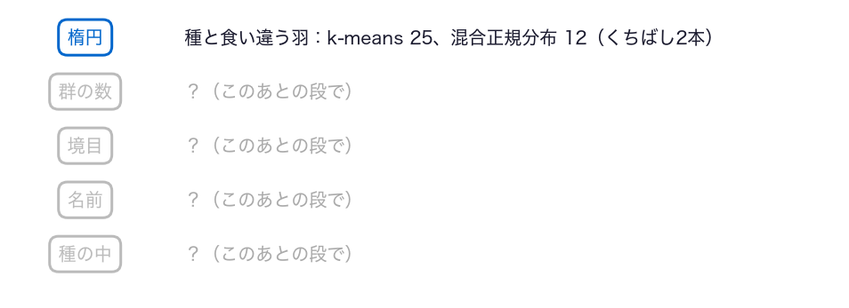

- まだ分からないのは、群の数を3と決めずに、データから選べるか

## ノートへ：0・1節

1節 15 ノートへ●

- 0・1節のセルを上から実行し、スライドと同じ数が出るか確かめる
- 予想を書く：群の数をデータに選ばせたら、3を選ぶか
- TODO①：予想を書く → `cols2`を`cols`に替えて実行 → 予想と比べる

動画の人は、ここで一時停止。

## 答え合わせ：TODO①

1節 16 答え合わせ●

```
くちばし2本 25 12
4本 29 5
```

- 4本にすると、混合正規分布の食い違いは5羽に減る。k-meansは、かえって増える
- ここから、4本の列を使う

# 2. 何種類とみなせる？

## 段2：群の数を選ぶ

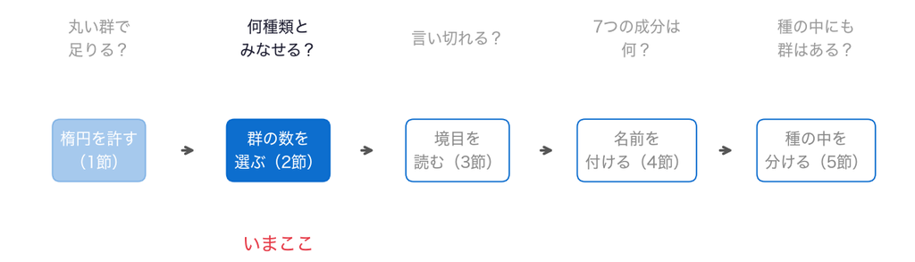

- 問い：群の数を決めずに、データから何種類とみなせるか

## 前の段から

2節 ① 前の段から●

- 種ごとの斜めの楕円を、混合正規分布はなぞれる。k-meansは丸で切る
- 4本の列で3つに分けると、種と食い違うのは5羽
- ここまで、群の数3は、こちらで決めて渡してきた

## お手本：4本を標準化

2節 ② 4本●

```python
X = StandardScaler().fit_transform(df[cols])
print(X.shape)
```

```
(342, 4)
```

- 1行目：4本の列をそろえて、配列`X`にする。2行目：形（羽の数×列の数）を見る

## 群の数を選ぶ物差し

2節 ③ BIC●○

- 混合正規分布は、データがどのくらい出てきやすいか（尤度）で、当てはまりを測れる
- 成分を増やすと、尤度は上がり続ける。それでは数が決まらない
- そこで、成分を増やした分のペナルティを付けて比べる

## 式：BIC

2節 ③ BIC●●

$$\mathrm{BIC} = -2\,\ell + d \log n$$

- $\ell$ は対数尤度（当てはまりのよさ）、$d$ はパラメータの数、$n$ は羽の数
- 第1項は当てはまりの悪さ、第2項は成分を増やした分のペナルティ
- 小さいほどよい。いちばん小さい群の数を選ぶ

## お手本：群の数ごとのBIC

2節 ④ BICを出す●○○

```python
bic_full = []
for k in range(1, 9):
    gm_k = GaussianMixture(k, n_init=5, random_state=0)
    gm_k.fit(X)
    bic_full.append(round(gm_k.bic(X)))
print(bic_full)
```

```
[3118, 2587, 2554, 2601, 2661, 2718, 2788, 2815]
```

## 1行ずつ：群の数ごとのBIC

2節 ④ BICを出す●●○

```python
bic_full = []
for k in range(1, 9):
    gm_k = GaussianMixture(k, n_init=5, random_state=0)
    gm_k.fit(X)
    bic_full.append(round(gm_k.bic(X)))
print(bic_full)
```

- 1行目：空のリストを用意する（第4回）
- 2〜4行目：成分の数`k`を1から8まで替えて、当てはめる
- 5・6行目：BIC（`bic`）を整数に丸めてためる。8つを表示する

## 中身を見る：3回だけ

2節 ④ BICを出す●●●

```python
bic_b = []
for k in range(1, 4):
    gm_k = GaussianMixture(k, n_init=5, random_state=0)
    gm_k.fit(X)
    bic_b.append(round(gm_k.bic(X)))
    print(k, bic_b)
```

```
1 [3118]
2 [3118, 2587]
3 [3118, 2587, 2554]
```

- 3がいちばん小さい。種の数と同じ

## 群の形には、型がある

2節 ⑤ 型●○

| 型（`covariance_type`） | 群の形 |
| --- | --- |
| `full` | 群ごとに、広がりも傾きも違う楕円 |
| `tied` | どの群も、同じ形の楕円 |
| `diag` | 群ごとに違うが、軸に沿った楕円（傾かない） |
| `spherical` | 群ごとに大きさの違う丸 |

- 上のお手本は、何も書かないので`full`だった

## 型を図で

2節 ⑤ 型●●

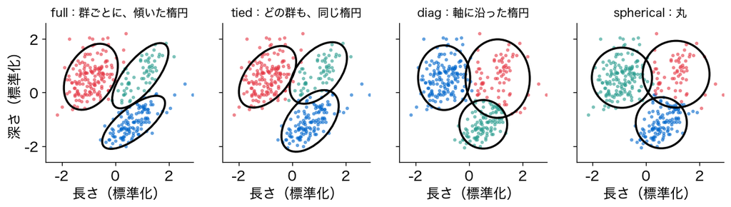

- くちばし2本で、型ごとに3つに分けた。型が狭いほど、斜めの塊をなぞれない

## 型と数の、すべての組

2節 ⑥ 入れ子のfor●○○○

- 型を替えても、BICで選ぶ数は3だろうか
- 型4つ×群の数8つ、すべての組でBICを出したい
- `for`の中に、もう1つ`for`を入れる

## 入れ子のfor：最小の例

2節 ⑥ 入れ子のfor●●○○

```python
for t in ['丸', '楕円']:
    for k in [1, 2, 3]:
        print(t, k)
```

```
丸 1   丸 2   丸 3
楕円 1   楕円 2   楕円 3
```

## 1行ずつ：入れ子のfor

2節 ⑥ 入れ子のfor●●●○

```python
for t in ['丸', '楕円']:
    for k in [1, 2, 3]:
        print(t, k)
```

- 1行目：外側。`t`に「丸」「楕円」を順に入れる
- 2行目：内側。外側の1回ごとに、`k`に1・2・3を全部入れる
- 3行目：組を表示する。外側2回×内側3回で、6回

## 入れ子のforがしていること

2節 ⑥ 入れ子のfor●●●●

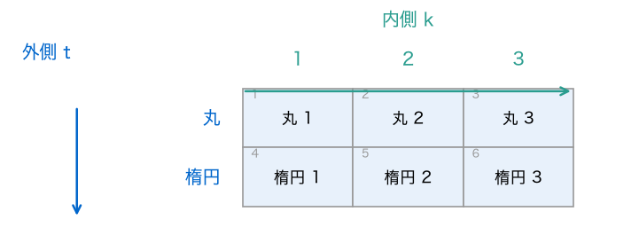

- 外側の1回ごとに、内側が全部回り、表が1行ずつ埋まる（小さな数は順番）

## お手本：型と数のBICの表

2節 ⑦ BICの表●○○○○○

```python
types = ['full', 'tied', 'diag', 'spherical']
bic = {}
for t in types:
    bic[t] = []
    for k in range(1, 9):
        gm_k = GaussianMixture(k, covariance_type=t, n_init=5,
                               random_state=0)
        gm_k.fit(X)
        bic[t].append(round(gm_k.bic(X)))
tab = pd.DataFrame(bic, index=range(1, 9))
tab
```

|  | 1 | 2 | 3 | 4 | 5 | 6 | 7 | 8 |
| --- | --- | --- | --- | --- | --- | --- | --- | --- |
| full | 3118 | 2587 | 2554 | 2601 | 2661 | 2718 | 2788 | 2815 |
| tied | 3118 | 2667 | 2516 | 2501 | 2521 | 2531 | 2541 | 2556 |
| diag | 3929 | 3029 | 2880 | 2686 | 2669 | 2666 | 2654 | 2683 |
| spherical | 3911 | 3147 | 2926 | 2713 | 2624 | 2592 | 2572 | 2593 |

- 表示は、行と列を入れ替えて見やすくした（ノートでは縦長の表）

## 1行ずつ：BICの表①

2節 ⑦ BICの表●●○○○○

```python
types = ['full', 'tied', 'diag', 'spherical']
bic = {}
for t in types:
    bic[t] = []
    for k in range(1, 9):
        gm_k = GaussianMixture(k, covariance_type=t, n_init=5,
                               random_state=0)
        gm_k.fit(X)
        bic[t].append(round(gm_k.bic(X)))
tab = pd.DataFrame(bic, index=range(1, 9))
tab
```

- 1・2行目：4つの型のリストと、結果をためる空の辞書（第5回）を作る
- 3行目：外側。型`t`を1つずつ取る
- 4行目：その型の鍵に、空のリストを入れる

## 1行ずつ：BICの表②

2節 ⑦ BICの表●●●○○○

```python
types = ['full', 'tied', 'diag', 'spherical']
bic = {}
for t in types:
    bic[t] = []
    for k in range(1, 9):
        gm_k = GaussianMixture(k, covariance_type=t, n_init=5,
                               random_state=0)
        gm_k.fit(X)
        bic[t].append(round(gm_k.bic(X)))
tab = pd.DataFrame(bic, index=range(1, 9))
tab
```

- 5〜8行目：内側。群の数`k`を1から8まで替え、型`t`で当てはめる
- 9行目：BICを、その型のリストの後ろに足す
- 10・11行目：辞書を表にする。行が群の数、列が型

## 中身を見る：2つの型、2つの数

2節 ⑦ BICの表●●●●○○

```python
bic_b = {}
for t in ['full', 'spherical']:
    bic_b[t] = []
    for k in range(1, 3):
        gm_k = GaussianMixture(k, covariance_type=t, n_init=5,
                               random_state=0)
        gm_k.fit(X)
        bic_b[t].append(round(gm_k.bic(X)))
        print(t, k, bic_b)
```

```
full 1 {'full': [3118]}
full 2 {'full': [3118, 2587]}
spherical 1 {'full': [3118, 2587], 'spherical': [3911]}
spherical 2 {'full': [3118, 2587], 'spherical': [3911, 3147]}
```

## 表が1行ずつ埋まる

2節 ⑦ BICの表●●●●●○

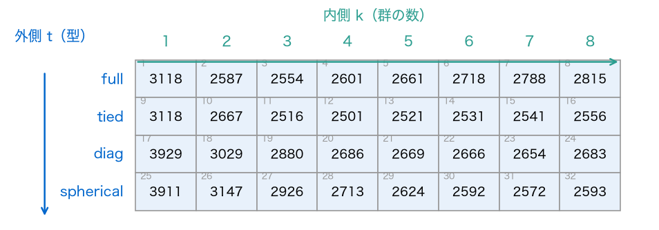

- 外側の型が1つ進むごとに、内側の群の数が1から8まで全部回る

## 重要概念：入れ子のfor

2節 ⑦ BICの表●●●●●●

forの中にforを入れると、外側の1回ごとに、内側が全部回る。2つの選び方の、すべての組を試せる。

## お手本：型ごとに選ばれる数

2節 ⑧ 選ばれる数●○

```python
print(tab.idxmin())
```

```
full         3
tied         4
diag         7
spherical    7
dtype: int64
```

- 1行目：列（型）ごとに、BICがいちばん小さい行（群の数）を表示する（`idxmin`）

## えっ、丸だと7つ

2節 ⑧ 選ばれる数●●

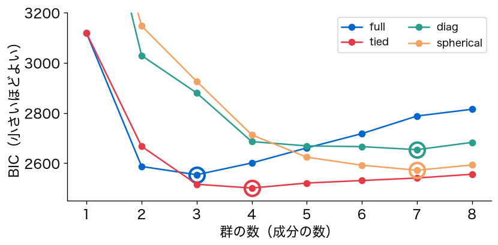

- 楕円の型（full）は3。丸の型（spherical）と、軸に沿った楕円（diag）は7

## なぜ7つ？

2節 ⑨ なぜ●○○

- 丸の型では、種ごとの斜めの楕円を、1つの丸では覆えない
- そこで、小さな丸をいくつも並べて、継ぎはぎする
- BICが選ぶのは、その形のもとで、データにいちばん近い重ね方

## 重要概念：成分は群とは限らない

2節 ⑨ なぜ●●○

BICが選ぶのは、置いた形の正規分布を何個重ねるかで、群の数ではない。形の仮定を替えると、選ばれる数も変わる。

## 表全体でも、3ではない

2節 ⑨ なぜ●●●

```python
print(tab.min())
```

```
full         2554
tied         2501
diag         2654
spherical    2572
dtype: int64
```

- 表全体でいちばん小さいのは、`tied`の4つ（2501）。「BICで選べば種の数」とは言えない

## TODO②：列を2本にする

2節 10 列を替える●○

```python
# TODO: cols を cols2 に替えて実行する
X_x = StandardScaler().fit_transform(df[cols])
bic_x = {}
for t in types:
    bic_x[t] = []
    for k in range(1, 9):
        gm_k = GaussianMixture(k, covariance_type=t, n_init=5,
                               random_state=0)
        gm_k.fit(X_x)
        bic_x[t].append(round(gm_k.bic(X_x)))
print(pd.DataFrame(bic_x, index=range(1, 9)).idxmin())
```

- 予想：くちばし2本にすると、丸の型はまだ7つを選ぶか

## ここまでで分かったこと

2節 10 列を替える●●

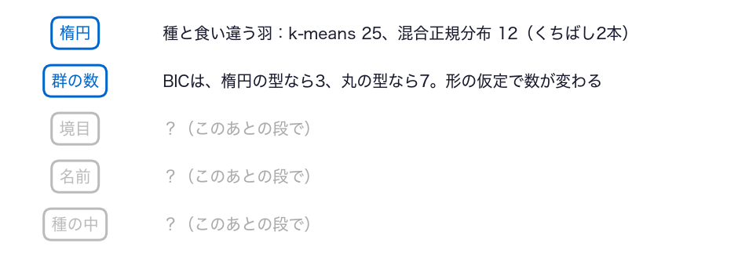

- まだ分からないのは、群に分けた1羽1羽を、言い切ってよいか

## ノートへ：2節

2節 11 ノートへ●

- 2節のセルを上から実行し、スライドと同じ数が出るか確かめる
- TODO②：予想を書く → `cols`を`cols2`に替えて実行 → 予想と比べる

動画の人は、ここで一時停止。

## 答え合わせ：TODO②

2節 12 答え合わせ●

```
full         3
tied         4
diag         4
spherical    4
dtype: int64
```

- くちばし2本では、楕円の型が3、ほかの3つの型は4を選ぶ
- 使う列を替えても、選ばれる数は変わる。数は、列と形の仮定しだい

# 3. 言い切れる？

## 段3：境目を読む

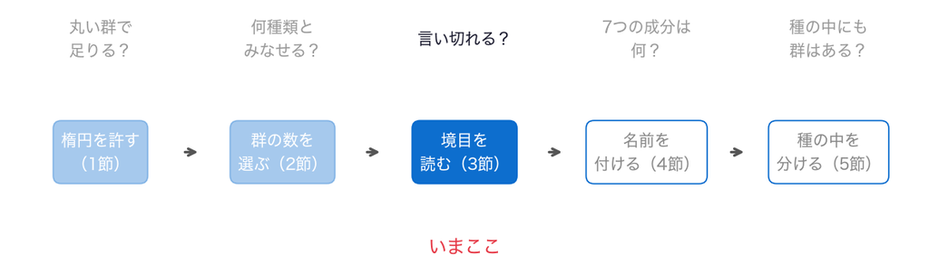

- 問い：群に分けた1羽1羽を、その群だと言い切ってよいか

## 前の段から

- BICで選ぶ数は、形の仮定しだい。楕円の型なら3、丸の型なら7
- 楕円の型で3つに分けると、種とよく合う
- ここから、楕円の型で3つに分けた結果を、1羽ずつ読む

## 確率で言える

3節 ① 確率●○

- 第8回のk-meansは、どの星も1つの群に言い切った
- 混合正規分布は、各成分から出てきたらしさを、確率で出せる
- 境目の羽は、どちらとも言い切れない、と言える

## 式：所属の確率

3節 ① 確率●●

羽 $i$ が成分 $j$ から出てきた確率：

$$P(j \mid x_i) = \frac{\pi_j \, N(x_i \mid \mu_j, \Sigma_j)}{\sum_{l=1}^{k} \pi_l \, N(x_i \mid \mu_l, \Sigma_l)}$$

- 分子は、成分 $j$ の割合と出てきやすさ。分母は、全部の成分の和
- 1羽について、$k$ 個の確率を足すと1

## お手本：所属の確率

3節 ② 所属の確率●○○

```python
gm = GaussianMixture(3, n_init=5, random_state=0)
gm.fit(X)
P = gm.predict_proba(X)
print(P[:3].round(3))
```

```
[[0.    1.    0.   ]
 [0.    0.999 0.001]
 [0.    0.974 0.026]]
```

## 1行ずつ：所属の確率

3節 ② 所属の確率●●○

```python
gm = GaussianMixture(3, n_init=5, random_state=0)
gm.fit(X)
P = gm.predict_proba(X)
print(P[:3].round(3))
```

- 1・2行目：4本の列で、楕円の型（full）の3成分を当てはめる
- 3行目：羽ごとに、3つの成分の確率を出す（`predict_proba`）。1行が1羽
- 4行目：先頭3羽の確率を見る

## 中身を見る：1羽ぶん

3節 ② 所属の確率●●●

```python
print(P[72].round(3), P[72].sum().round(3))
```

```
[0.    0.265 0.735] 1.0
```

- 72番の羽は、2つの成分のあいだで迷っている。3つを足すと1

## お手本：言い切れない羽を数える

3節 ③ 数える●○○

```python
pmax = P.max(axis=1)
print((pmax < 0.9).sum(), '羽')
```

```
7 羽
```

## 1行ずつ：言い切れない羽を数える

3節 ③ 数える●●○

```python
pmax = P.max(axis=1)
print((pmax < 0.9).sum(), '羽')
```

- 1行目：羽ごとに、3つの確率のうちいちばん大きいものを取る（`axis=1`は横に）
- 2行目：それが0.9に届かない羽を数える（Trueを1として足す）

## お手本：言い切れない羽を見る

3節 ③ 数える●●●

```python
df[pmax < 0.9][['種', '性別', 'くちばしの長さ', 'くちばしの深さ']]
```

|  | 種 | 性別 | くちばしの長さ | くちばしの深さ |
| --- | --- | --- | --- | --- |
| 72 | アデリー | オス | 45.8 | 18.9 |
| 130 | アデリー | オス | 43.1 | 19.2 |
| 277 | ヒゲ | メス | 45.4 | 18.7 |
| 282 | ヒゲ | メス | 46.0 | 18.9 |
| 304 | ヒゲ | メス | 40.9 | 16.6 |
| 306 | ヒゲ | メス | 42.5 | 16.7 |
| 328 | ヒゲ | メス | 42.5 | 17.3 |

- 条件に合う行だけを取り出し、4本の列を見る

## お手本：境目に印を付ける

3節 ④ 境目●○○○

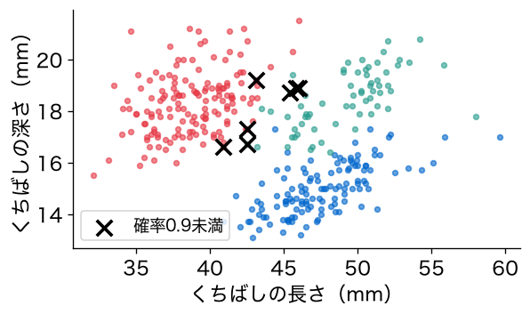

```python
plt.scatter(df['くちばしの長さ'], df['くちばしの深さ'], s=10,
            c=gm.predict(X))
amb = df[pmax < 0.9]
plt.scatter(amb['くちばしの長さ'], amb['くちばしの深さ'], s=80,
            marker='x', color='black')
plt.xlabel('くちばしの長さ（mm）')
plt.ylabel('くちばしの深さ（mm）')
plt.show()
```

## 1行ずつ：境目に印を付ける

3節 ④ 境目●●○○

```python
plt.scatter(df['くちばしの長さ'], df['くちばしの深さ'], s=10,
            c=gm.predict(X))
amb = df[pmax < 0.9]
plt.scatter(amb['くちばしの長さ'], amb['くちばしの深さ'], s=80,
            marker='x', color='black')
plt.xlabel('くちばしの長さ（mm）')
plt.ylabel('くちばしの深さ（mm）')
plt.show()
```

- 1・2行目：全部の羽を、いちばん出てきたらしい成分の色で打つ
- 3行目：言い切れない羽だけの表`amb`を作る
- 4・5行目：その羽に、黒い×を大きく重ねる

## 境目にいるのは

3節 ④ 境目●●●○

- ×は、アデリーとヒゲの塊のあいだにいる
- 7羽のうち5羽は、ヒゲのメス。小さめのヒゲは、アデリーに似る
- k-meansでは、この羽も、どれか1つの群に言い切られていた

## 重要：所属を確率で言う

3節 ④ 境目●●●●

混合正規分布は、どの群に入るかを確率で言える。言い切れない点を、言い切れないまま残せる。

## TODO③：しきい値を替える

3節 ⑤ しきい値●○

```python
# TODO: 0.9 を 0.6 に替えて実行する
print((pmax < 0.9).sum(), '羽')
```

- 予想：0.6に届かない羽は、何羽になるか

## ここまでで分かったこと

3節 ⑤ しきい値●●

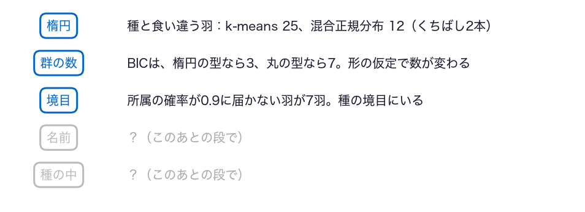

- まだ分からないのは、丸の型が選んだ7つの成分は、何の群か

## ノートへ：3節

3節 ⑥ ノートへ●

- 3節のセルを上から実行し、スライドと同じ数が出るか確かめる
- TODO③：予想を書く → `0.9`を`0.6`に替えて実行 → 予想と比べる

動画の人は、ここで一時停止。

## 答え合わせ：TODO③

3節 ⑦ 答え合わせ●

```
2 羽
```

- 0.6に届かない羽は2羽。ほぼ半々で迷っている羽は、わずか
- しきい値は、こちらが決める。決めた値をレポートに書く

# 4. 7つの成分は何？

## 段4：名前を付ける

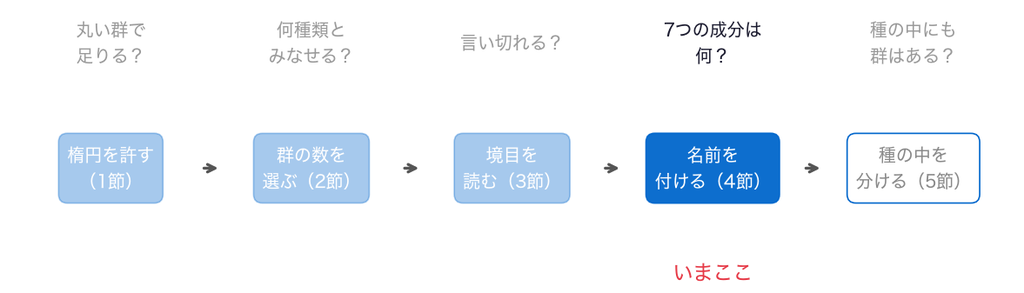

- 問い：丸の型でBICが選んだ7つの成分は、何の群か

## 前の段から

- 混合正規分布は、所属を確率で言える。言い切れない羽は7羽
- 丸の型のBICは7つを選んだ。種は3つなのに
- ここから、7つの成分に名前を付け、使わなかった列で確かめる

## お手本：丸の型で7つに

4節 ① 7つに分ける●○

```python
gm7 = GaussianMixture(7, covariance_type='spherical', n_init=5,
                      random_state=0)
gm7.fit(X)
df['成分'] = gm7.predict(X)
print(df['成分'].value_counts().sort_index().tolist())
```

```
[36, 38, 95, 33, 25, 63, 52]
```

## 1行ずつ：丸の型で7つに

4節 ① 7つに分ける●●

```python
gm7 = GaussianMixture(7, covariance_type='spherical', n_init=5,
                      random_state=0)
gm7.fit(X)
df['成分'] = gm7.predict(X)
print(df['成分'].value_counts().sort_index().tolist())
```

- 1〜3行目：丸の型で、成分の数7で当てはめる
- 4行目：羽ごとの成分の番号を、列「成分」にする
- 5行目：成分0から6の順に、羽の数を表示する

## お手本：成分ごとの平均

4節 ② 平均で読む●○○

```python
df.groupby('成分')[cols].mean().round(0)
```

| 成分 | くちばしの長さ | くちばしの深さ | ひれの長さ | 体重 |
| --- | --- | --- | --- | --- |
| 0 | 51.0 | 19.0 | 200.0 | 3925.0 |
| 1 | 48.0 | 15.0 | 217.0 | 5197.0 |
| 2 | 38.0 | 18.0 | 187.0 | 3402.0 |
| 3 | 51.0 | 16.0 | 225.0 | 5664.0 |
| 4 | 47.0 | 18.0 | 192.0 | 3539.0 |
| 5 | 41.0 | 19.0 | 194.0 | 4121.0 |
| 6 | 45.0 | 14.0 | 212.0 | 4614.0 |

## 1行ずつ：成分ごとの平均

4節 ② 平均で読む●●○

```python
df.groupby('成分')[cols].mean().round(0)
```

- 1行目：成分ごとに羽を分け（`groupby`）、4本の列の平均を出す
- ひれが長く重い成分が3つ、くちばしが短い成分が2つ、くちばしが長く深い成分が2つ

## 名前の候補

4節 ② 平均で読む●●●

- ひれが長く重い3つは、ジェンツーらしい
- くちばしが短い2つはアデリー、長く深い2つはヒゲらしい
- 同じ種らしい成分のあいだでは、体重が違う

## お手本：種と突き合わせる

4節 ③ 突き合わせ●○○○

```python
pd.crosstab(df['種'], df['成分'])
```

| 成分 種 | 0 | 1 | 2 | 3 | 4 | 5 | 6 |
| --- | --- | --- | --- | --- | --- | --- | --- |
| アデリー | 0 | 0 | 90 | 0 | 0 | 61 | 0 |
| ジェンツー | 0 | 38 | 0 | 33 | 0 | 0 | 52 |
| ヒゲ | 36 | 0 | 5 | 0 | 25 | 2 | 0 |

- 1行目：種と成分の組ごとに、羽を数える

## 1つの種が、いくつかの成分に

4節 ③ 突き合わせ●●○○

- どの成分も、ほぼ1つの種だけ。名前の候補は合っていた
- ただし、1つの種が2つか3つの成分に分かれた
- では、種の中の何で分かれたのか

## お手本：島と突き合わせる

4節 ③ 突き合わせ●●●○

```python
pd.crosstab(df['島'], df['成分'])
```

| 成分 島 | 0 | 1 | 2 | 3 | 4 | 5 | 6 |
| --- | --- | --- | --- | --- | --- | --- | --- |
| トージャーセン | 0 | 0 | 29 | 0 | 0 | 22 | 0 |
| ドリーム | 36 | 0 | 40 | 0 | 25 | 23 | 0 |
| ビスコー | 0 | 38 | 26 | 33 | 0 | 18 | 52 |

- アデリーらしい成分は、3つの島すべてにまたがる。島では分かれていない

## 重要：名前は確かめて付ける

4節 ③ 突き合わせ●●●●

成分ごとの平均から付けた名前は、候補にすぎない。使わなかった列と突き合わせて、確かめてから名前にする。

## TODO④：突き合わせる列を替える

4節 ④ 列を替える●○

```python
# TODO: '島' を '性別' に替えて実行する
pd.crosstab(df['島'], df['成分'])
```

- 予想：性別と突き合わせると、同じ種の成分どうしは、オスとメスに分かれているか

## ここまでで分かったこと

4節 ④ 列を替える●●

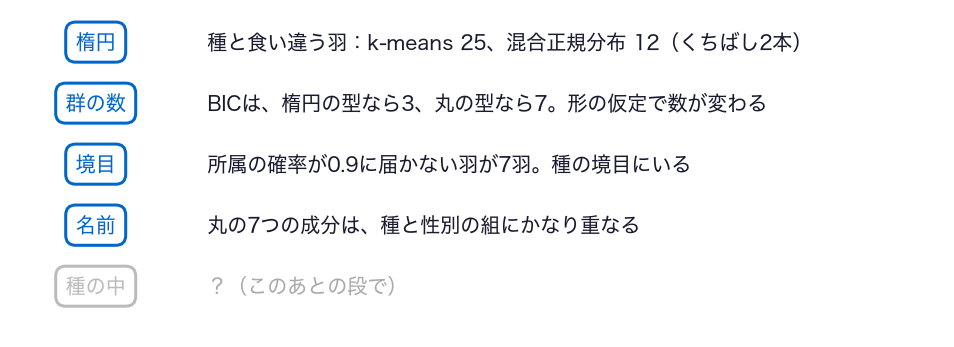

- まだ分からないのは、楕円の型でも、種の中にオスとメスの群が見つかるか

## ノートへ：4節

4節 ⑤ ノートへ●

- 4節のセルを上から実行し、スライドと同じ数が出るか確かめる
- TODO④：予想を書く → `'島'`を`'性別'`に替えて実行 → 予想と比べる

動画の人は、ここで一時停止。

## 答え合わせ：TODO④

4節 ⑥ 答え合わせ●○

| 成分 性別 | 0 | 1 | 2 | 3 | 4 | 5 | 6 |
| --- | --- | --- | --- | --- | --- | --- | --- |
| オス | 32 | 28 | 14 | 33 | 2 | 59 | 0 |
| メス | 4 | 9 | 77 | 0 | 23 | 3 | 49 |

- 同じ種の成分どうしは、オスの成分とメスの成分に分かれていた（性別が欠測の9羽は数に入らない）

## 7つの正体

4節 ⑥ 答え合わせ●●

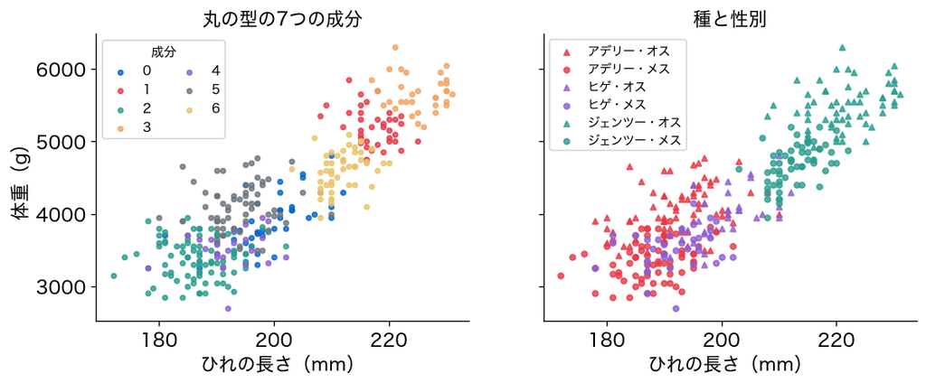

- オスはメスより大きい。丸の型は、種の中のオスとメスの違いまで、別の成分にした

# 5. 種の中にも群はある？

## 段5：種の中を分ける

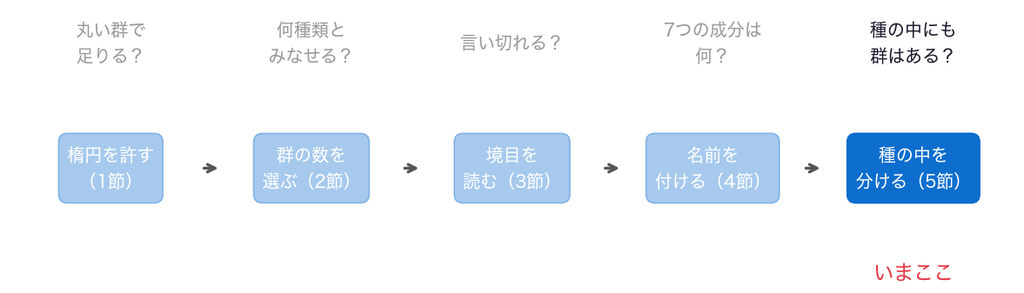

- 問い：楕円の型で1つの種だけを分けても、オスとメスの群は見つかるか

## 前の段から

- 丸の型の7つの成分は、種とオス・メスの組にかなり重なった
- 丸の型は、斜めの楕円を継ぎはぎするので、余った成分ができやすい
- 楕円を許す型でも、種の中に群はあるのか

## 種の中で2つに分ける

5節 ① 種の中●

- 1つの種の羽だけを取り出し、4本の列を、その種の中で標準化する
- 楕円の型（full）で、成分の数2で分ける
- 性別は使わない。分けたあとの答え合わせだけに使う

## お手本：ジェンツーだけを2つに

5節 ② ジェンツー●○○

```python
gen = df[df['種'] == 'ジェンツー']
Xg = StandardScaler().fit_transform(gen[cols])
gm_g = GaussianMixture(2, n_init=5, random_state=0)
gm_g.fit(Xg)
pd.crosstab(gen['性別'], gm_g.predict(Xg))
```

| col_0 性別 | 0 | 1 |
| --- | --- | --- |
| オス | 48 | 13 |
| メス | 0 | 58 |

## 1行ずつ：ジェンツーだけを2つに

5節 ② ジェンツー●●○

```python
gen = df[df['種'] == 'ジェンツー']
Xg = StandardScaler().fit_transform(gen[cols])
gm_g = GaussianMixture(2, n_init=5, random_state=0)
gm_g.fit(Xg)
pd.crosstab(gen['性別'], gm_g.predict(Xg))
```

- 1・2行目：ジェンツーの羽だけを取り出し、4本の列を標準化する
- 3・4行目：楕円の型で、成分の数2で当てはめる
- 5行目：性別と成分の組ごとに数える

## 中身を見る：成分ごとの平均

5節 ② ジェンツー●●●

```python
gen.groupby(gm_g.predict(Xg))[cols].mean().round(0)
```

|  | くちばしの長さ | くちばしの深さ | ひれの長さ | 体重 |
| --- | --- | --- | --- | --- |
| 0 | 50.0 | 16.0 | 222.0 | 5592.0 |
| 1 | 46.0 | 14.0 | 214.0 | 4746.0 |

- 成分0は、くちばしが長く深く、ひれが長く、重い。オスらしい

## オスとメスが分かれた

5節 ③ 読む●○

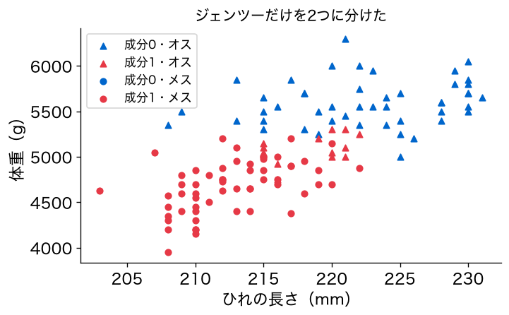

- メス（丸）は、すべて成分1。オス（三角）は多くが成分0で、小さめのオスが成分1にまざる

## 重要：群の中にも群がある

5節 ③ 読む●●

種という群の中にも、オスとメスという群がある。データはどちらにも分けられるので、何を群と呼ぶかは、問いが決める。

## TODO⑤：種を替える

5節 ④ 種を替える●○

```python
# TODO: 'ジェンツー' を 'アデリー' に替えて実行する
sp = df[df['種'] == 'ジェンツー']
Xs = StandardScaler().fit_transform(sp[cols])
gm_s = GaussianMixture(2, n_init=5, random_state=0)
gm_s.fit(Xs)
pd.crosstab(sp['性別'], gm_s.predict(Xs))
```

- 予想：アデリーでも、メスは1つの成分にまとまるか

## ここまでで分かったこと

5節 ④ 種を替える●●

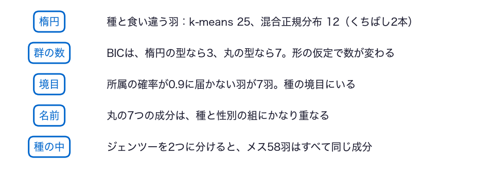

- 5つの段がそろい、今日の問いに答えられる

## ノートへ：5節

5節 ⑤ ノートへ●

- 5節のセルを上から実行し、スライドと同じ数が出るか確かめる
- TODO⑤：予想を書く → `'ジェンツー'`を`'アデリー'`に替えて実行 → 予想と比べる

動画の人は、ここで一時停止。

## 答え合わせ：TODO⑤

5節 ⑥ 答え合わせ●

| col_0 性別 | 0 | 1 |
| --- | --- | --- |
| オス | 21 | 52 |
| メス | 72 | 1 |

- アデリーでは、メス73羽のうち72羽が成分0。オス73羽のうち52羽が成分1
- ジェンツーと同じく、オスとメスにかなり分かれる。小さめのオスが、メスの成分にまざる

## 答え：3種は分かれる

5節 ⑦ 答え●

- 楕円を許す混合正規分布なら、体の測り方だけで3種はほぼ分かれる（食い違い5羽）
- BICが選ぶ数は、型と列しだいで、3にも4にも7にもなる
- 丸の型の7つは、種とオス・メスの組。余った成分にも、意味があった

## まだ言えないこと

5節 ⑧ まだ言えないこと●

- どの型が正しいかは、データだけでは決まらない
- 種を群と呼ぶか、種とオス・メスの組を群と呼ぶかは、問いが決める
- 性別が欠測の9羽が、どちらの性別か

# まとめ

## 今日の道筋を振り返る

⑨ 振り返る●○○○

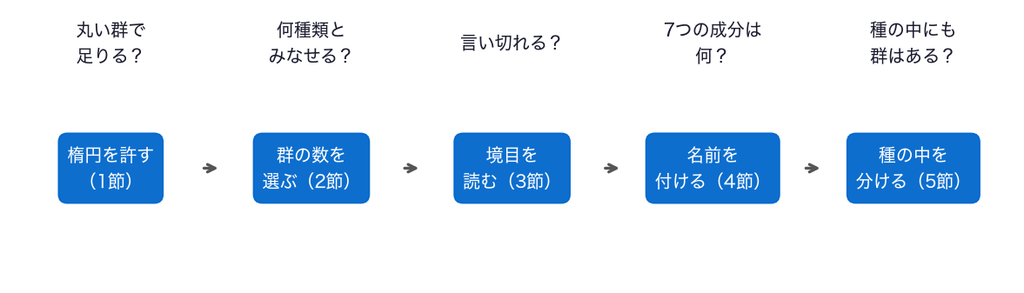

- 楕円を許して分け、BICで数を選び、所属の確率で境目を読み、成分に名前を付け、種の中を分けた

## 今日持ち帰る1文

⑨ 振り返る●●○○

混合正規分布は、群ごとに楕円を許し、所属を確率で言う。BICが選ぶのは置いた形の成分の数で、群の数ではない。名前は、使わなかった列で確かめて付ける。

## 今日の重要概念

⑨ 振り返る●●●○

統計：成分は群とは限らない。BICが選ぶのは、置いた形の正規分布を何個重ねるかで、群の数ではない。形の仮定を替えると、選ばれる数も変わる。

Python：入れ子のfor。forの中にforを入れると、外側の1回ごとに、内側が全部回る。2つの選び方の、すべての組を試せる。

## 今日の要点

⑨ 振り返る●●●●

- k-meansは丸い群、混合正規分布は楕円の群を探す
- 混合正規分布は、所属を確率で言える。言い切れない点が分かる
- 群の名前は候補。使わなかった列と突き合わせて確かめる

## レポートなら、こう書く①

10 レポートなら●○

- 予想：体の測り方だけで、3種に分かれるだろう
- 解析：4本の列を標準化し、混合正規分布で3つに分けた。種と食い違うのは5羽
- 群の数：型4つ×群の数1〜8のBICを比べた。楕円の型は3、丸の型は7

## レポートなら、こう書く②

10 レポートなら●●

- 驚き：丸の型の7つの成分は、種とオス・メスの組だった
- 境目：所属の確率が0.9に届かない羽が7羽。多くはヒゲのメス
- 限界：BICの数は、型と列の選び方しだい。何を群と呼ぶかは、問いで決めた

## 課題の出し方

11 このあと●○○

- 今日の重要概念は、統計の「成分は群とは限らない」と、Pythonの「入れ子のfor」
- 2つを1枚ずつ絵にし、2枚をLACSに提出（＝出席。期限なし）
- 手描きの写真でも、描画アプリでもよい。上手でなくてよい

## 次回の問い

11 このあと●●○

- 今日は、群を見つけ、その数を選んだ
- では、2つの組に差が見えたとき、その差は偶然でも出る差ではないか

## このあと：課題へ

11 このあと●●●

- ノートの最後の「課題（提出）」を開く
- 絵を描き終えたら、このあとの「解答」で、絵の例と見比べる

# ここから先は解答

## 課題のあとで見る

- ここから先は、課題の絵を描き終えてから見る
- 絵の例を2つ見せる。上手さではなく、考えが伝わるかを見比べる

## 絵の例：成分は群とは限らない

- 細長い廊下と丸い部屋の床に、丸いマットだけを敷いていく
- 丸い部屋は1枚で足りる。細長い廊下は、何枚も並べないと覆えない
- マットの枚数は、部屋の数ではない。マットの形しだいで、枚数が変わる

## 絵の例：入れ子のfor

- 九九の表を、1の段から順に埋める
- 1の段（外側の1回）のあいだに、1から9（内側）を全部かける
- 段が1つ進むごとに、表が1行ずつ埋まる

# 発展（任意）

## 性別が欠測の羽を推す

- アデリーには、性別が欠測の羽が5羽いる
- 種の中で2つに分けた成分は、オスとメスにかなり重なった
- 欠測の羽が、どちらの成分にどれだけの確率で入るかを見る

## お手本：欠測の羽の所属の確率

```python
ade = df[df['種'] == 'アデリー']
Xa = StandardScaler().fit_transform(ade[cols])
gm_a = GaussianMixture(2, n_init=5, random_state=0)
gm_a.fit(Xa)
na = ade['性別'].isna().values
print(gm_a.predict_proba(Xa)[na].round(2))
```

```
[[0.98 0.02]
 [0.03 0.97]
 [1.   0.  ]
 [1.   0.  ]
 [1.   0.  ]]
```

## 5羽のうち4羽はメスの成分

- TODO⑤で、成分0はメス72羽と小さめのオス21羽、成分1はオス52羽とメス1羽だった
- 5羽のうち4羽は成分0（メスらしい）、1羽は成分1（オスらしい）に、確率0.97以上で入る
- ただし、成分0には小さめのオスもまざる。「メスらしい」は言えても、メスと決めつけはできない

## おわり

- お疲れさまでした